# Predictive Machine Maintenance Model (99 acc)

### Predictive Maintenance Classification on Machine Failure

#### Dataset from: https://www.kaggle.com/datasets/shivamb/machine-predictive-maintenance-classification

#### Created by: Goh Chia Ching

#### Date Updated 17 Jan 2024

### Introduction

This notebook aims to:

1. explore predictive modelling on unbalanced datasets using different classification techniques
2. create feasible and robust solutions for real world factory problems such as machinery maintenance

### Set Up and Libraries

```python
#setup
import pandas as pd
import numpy as np
import matplotlib.pyplot as plt
import seaborn as sns
import imblearn

%matplotlib inline
df = pd.read_csv("predictive_maintenance.csv")
```

### Data Exploration

```python
df.shape #to see the number of (rows, columns) in the dataframe
```

```
(10000, 10)
```

```python
df.info() #see a summary of the data, including count, and datatype
```

```
<class 'pandas.core.frame.DataFrame'>
RangeIndex: 10000 entries, 0 to 9999
Data columns (total 10 columns):
 #   Column                   Non-Null Count  Dtype
---  ------                   --------------  -----
 0   UDI                      10000 non-null  int64
 1   Product ID               10000 non-null  object
 2   Type                     10000 non-null  object
 3   Air temperature [K]      10000 non-null  float64
 4   Process temperature [K]  10000 non-null  float64
 5   Rotational speed [rpm]   10000 non-null  int64
 6   Torque [Nm]              10000 non-null  float64
 7   Tool wear [min]          10000 non-null  int64
 8   Target                   10000 non-null  int64
 9   Failure Type             10000 non-null  object
dtypes: float64(3), int64(4), object(3)
memory usage: 781.4+ KB
```

```python
df.head() #see first 5 records of the data as a sample
```

|  | UDI | Product ID | Type | Air temperature [K] | Process temperature [K] | Rotational speed [rpm] | Torque [Nm] | Tool wear [min] | Target | Failure Type |
| --- | --- | --- | --- | --- | --- | --- | --- | --- | --- | --- |
| 0 | 1 | M14860 | M | 298.1 | 308.6 | 1551 | 42.8 | 0 | 0 | No Failure |
| 1 | 2 | L47181 | L | 298.2 | 308.7 | 1408 | 46.3 | 3 | 0 | No Failure |
| 2 | 3 | L47182 | L | 298.1 | 308.5 | 1498 | 49.4 | 5 | 0 | No Failure |
| 3 | 4 | L47183 | L | 298.2 | 308.6 | 1433 | 39.5 | 7 | 0 | No Failure |
| 4 | 5 | L47184 | L | 298.2 | 308.7 | 1408 | 40.0 | 9 | 0 | No Failure |

```python
df.tail() #see last 4 records of the data as a sample
```

|  | UDI | Product ID | Type | Air temperature [K] | Process temperature [K] | Rotational speed [rpm] | Torque [Nm] | Tool wear [min] | Target | Failure Type |
| --- | --- | --- | --- | --- | --- | --- | --- | --- | --- | --- |
| 9995 | 9996 | M24855 | M | 298.8 | 308.4 | 1604 | 29.5 | 14 | 0 | No Failure |
| 9996 | 9997 | H39410 | H | 298.9 | 308.4 | 1632 | 31.8 | 17 | 0 | No Failure |
| 9997 | 9998 | M24857 | M | 299.0 | 308.6 | 1645 | 33.4 | 22 | 0 | No Failure |
| 9998 | 9999 | H39412 | H | 299.0 | 308.7 | 1408 | 48.5 | 25 | 0 | No Failure |
| 9999 | 10000 | M24859 | M | 299.0 | 308.7 | 1500 | 40.2 | 30 | 0 | No Failure |

```python
df.describe() #give statistical summary of the data
```

|  | UDI | Air temperature [K] | Process temperature [K] | Rotational speed [rpm] | Torque [Nm] | Tool wear [min] | Target |
| --- | --- | --- | --- | --- | --- | --- | --- |
| count | 10000.00000 | 10000.000000 | 10000.000000 | 10000.000000 | 10000.000000 | 10000.000000 | 10000.000000 |
| mean | 5000.50000 | 300.004930 | 310.005560 | 1538.776100 | 39.986910 | 107.951000 | 0.033900 |
| std | 2886.89568 | 2.000259 | 1.483734 | 179.284096 | 9.968934 | 63.654147 | 0.180981 |
| min | 1.00000 | 295.300000 | 305.700000 | 1168.000000 | 3.800000 | 0.000000 | 0.000000 |
| 25% | 2500.75000 | 298.300000 | 308.800000 | 1423.000000 | 33.200000 | 53.000000 | 0.000000 |
| 50% | 5000.50000 | 300.100000 | 310.100000 | 1503.000000 | 40.100000 | 108.000000 | 0.000000 |
| 75% | 7500.25000 | 301.500000 | 311.100000 | 1612.000000 | 46.800000 | 162.000000 | 0.000000 |
| max | 10000.00000 | 304.500000 | 313.800000 | 2886.000000 | 76.600000 | 253.000000 | 1.000000 |

```python
df.apply(lambda x: x.nunique()) #see the number of unique values per variable in the dataframe
```

```
UDI                        10000
Product ID                 10000
Type                           3
Air temperature [K]           93
Process temperature [K]       82
Rotational speed [rpm]       941
Torque [Nm]                  577
Tool wear [min]              246
Target                         2
Failure Type                   6
dtype: int64
```

Now we've established a very simple summary of the data.

We will now focus on estimating the Failure Type of the machine. In a more practical sense, models should first estimate whether a failure will occur or not then estimate the type of failure since a binary (yes/no) classification is faster and more accurate to predict in these situations. However for further complexity, we will be focusing on the Failure Type classification.

```python
np.unique(df['Failure Type'])
```

```
array(['Heat Dissipation Failure', 'No Failure', 'Overstrain Failure',
       'Power Failure', 'Random Failures', 'Tool Wear Failure'],
      dtype=object)
```

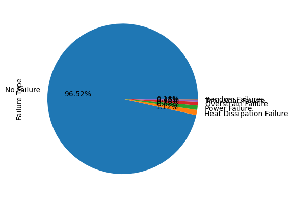

```python
ax = df['Failure Type'].value_counts().plot.pie(autopct='%1.2f%%')
```

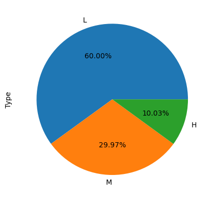

```python
ax = df['Type'].value_counts().plot.pie(autopct='%1.2f%%')
```

1. Stratified Sampling
2. Oversampling

Now we will look at the general shape of the data:

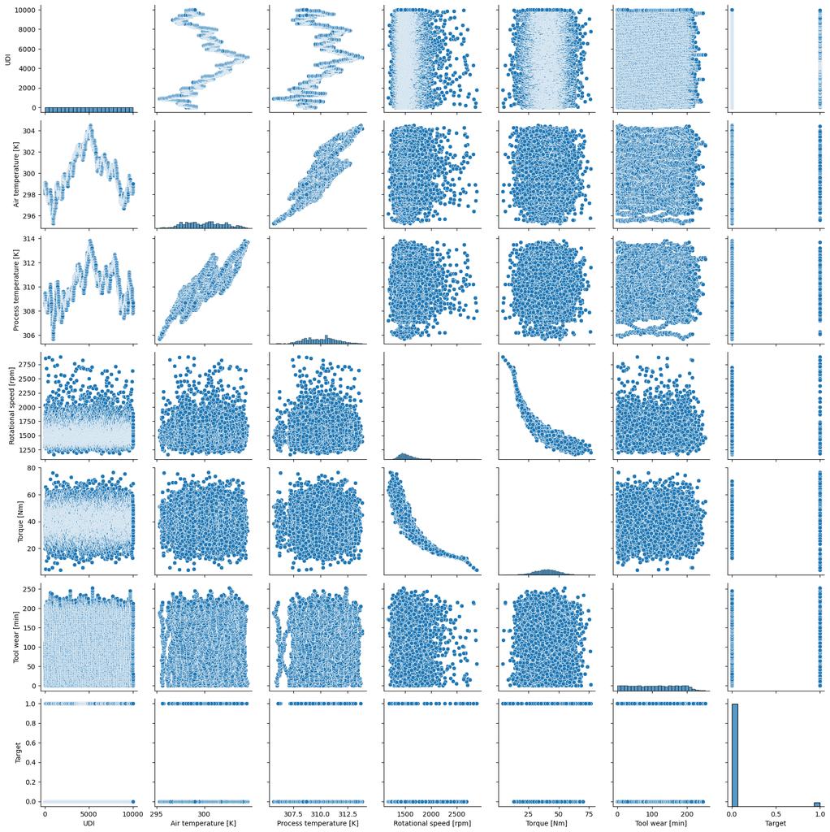

```python
sns.pairplot(df)
```

### Data Cleaning

```python
df['UDI'].nunique() #check if there are any repeated machines
```

```
10000
```

```python
df.dropna() #drop all NA values
```

|  | UDI | Product ID | Type | Air temperature [K] | Process temperature [K] | Rotational speed [rpm] | Torque [Nm] | Tool wear [min] | Target | Failure Type |
| --- | --- | --- | --- | --- | --- | --- | --- | --- | --- | --- |
| 0 | 1 | M14860 | M | 298.1 | 308.6 | 1551 | 42.8 | 0 | 0 | No Failure |
| 1 | 2 | L47181 | L | 298.2 | 308.7 | 1408 | 46.3 | 3 | 0 | No Failure |
| 2 | 3 | L47182 | L | 298.1 | 308.5 | 1498 | 49.4 | 5 | 0 | No Failure |
| 3 | 4 | L47183 | L | 298.2 | 308.6 | 1433 | 39.5 | 7 | 0 | No Failure |
| 4 | 5 | L47184 | L | 298.2 | 308.7 | 1408 | 40.0 | 9 | 0 | No Failure |
| ... | ... | ... | ... | ... | ... | ... | ... | ... | ... | ... |
| 9995 | 9996 | M24855 | M | 298.8 | 308.4 | 1604 | 29.5 | 14 | 0 | No Failure |
| 9996 | 9997 | H39410 | H | 298.9 | 308.4 | 1632 | 31.8 | 17 | 0 | No Failure |
| 9997 | 9998 | M24857 | M | 299.0 | 308.6 | 1645 | 33.4 | 22 | 0 | No Failure |
| 9998 | 9999 | H39412 | H | 299.0 | 308.7 | 1408 | 48.5 | 25 | 0 | No Failure |
| 9999 | 10000 | M24859 | M | 299.0 | 308.7 | 1500 | 40.2 | 30 | 0 | No Failure |

10000 rows × 10 columns

```python
#df.groupby('Failure Type').count()

#count number of 'no failures' based on failure type
df['Failure Type'].value_counts()
# the value tallies!
```

```
No Failure                  9652
Heat Dissipation Failure     112
Power Failure                 95
Overstrain Failure            78
Tool Wear Failure             45
Random Failures               18
Name: Failure Type, dtype: int64
```

```python
df.loc[df['Failure Type'] == 'No Failure', 'Failure Type'] = 1
df.loc[df['Failure Type'] == 'Heat Dissipation Failure', 'Failure Type'] = 2
df.loc[df['Failure Type'] == 'Overstrain Failure', 'Failure Type'] = 4
df.loc[df['Failure Type'] == 'Power Failure', 'Failure Type'] = 3
df.loc[df['Failure Type'] == 'Tool Wear Failure', 'Failure Type'] = 5
df.loc[df['Failure Type'] == 'Random Failures', 'Failure Type'] = 6
df
```

|  | UDI | Product ID | Type | Air temperature [K] | Process temperature [K] | Rotational speed [rpm] | Torque [Nm] | Tool wear [min] | Target | Failure Type |
| --- | --- | --- | --- | --- | --- | --- | --- | --- | --- | --- |
| 0 | 1 | M14860 | M | 298.1 | 308.6 | 1551 | 42.8 | 0 | 0 | 1 |
| 1 | 2 | L47181 | L | 298.2 | 308.7 | 1408 | 46.3 | 3 | 0 | 1 |
| 2 | 3 | L47182 | L | 298.1 | 308.5 | 1498 | 49.4 | 5 | 0 | 1 |
| 3 | 4 | L47183 | L | 298.2 | 308.6 | 1433 | 39.5 | 7 | 0 | 1 |
| 4 | 5 | L47184 | L | 298.2 | 308.7 | 1408 | 40.0 | 9 | 0 | 1 |
| ... | ... | ... | ... | ... | ... | ... | ... | ... | ... | ... |
| 9995 | 9996 | M24855 | M | 298.8 | 308.4 | 1604 | 29.5 | 14 | 0 | 1 |
| 9996 | 9997 | H39410 | H | 298.9 | 308.4 | 1632 | 31.8 | 17 | 0 | 1 |
| 9997 | 9998 | M24857 | M | 299.0 | 308.6 | 1645 | 33.4 | 22 | 0 | 1 |
| 9998 | 9999 | H39412 | H | 299.0 | 308.7 | 1408 | 48.5 | 25 | 0 | 1 |
| 9999 | 10000 | M24859 | M | 299.0 | 308.7 | 1500 | 40.2 | 30 | 0 | 1 |

10000 rows × 10 columns

```python
df['Failure Type'].value_counts()
```

```
1    9652
2     112
3      95
4      78
5      45
6      18
Name: Failure Type, dtype: int64
```

```python
df.loc[df["Type"] == "H", "Type"] = 3
df.loc[df["Type"] == "M", "Type"] = 2
df.loc[df["Type"] == "L", "Type"] = 1
df
```

|  | UDI | Product ID | Type | Air temperature [K] | Process temperature [K] | Rotational speed [rpm] | Torque [Nm] | Tool wear [min] | Target | Failure Type |
| --- | --- | --- | --- | --- | --- | --- | --- | --- | --- | --- |
| 0 | 1 | M14860 | 2 | 298.1 | 308.6 | 1551 | 42.8 | 0 | 0 | 1 |
| 1 | 2 | L47181 | 1 | 298.2 | 308.7 | 1408 | 46.3 | 3 | 0 | 1 |
| 2 | 3 | L47182 | 1 | 298.1 | 308.5 | 1498 | 49.4 | 5 | 0 | 1 |
| 3 | 4 | L47183 | 1 | 298.2 | 308.6 | 1433 | 39.5 | 7 | 0 | 1 |
| 4 | 5 | L47184 | 1 | 298.2 | 308.7 | 1408 | 40.0 | 9 | 0 | 1 |
| ... | ... | ... | ... | ... | ... | ... | ... | ... | ... | ... |
| 9995 | 9996 | M24855 | 2 | 298.8 | 308.4 | 1604 | 29.5 | 14 | 0 | 1 |
| 9996 | 9997 | H39410 | 3 | 298.9 | 308.4 | 1632 | 31.8 | 17 | 0 | 1 |
| 9997 | 9998 | M24857 | 2 | 299.0 | 308.6 | 1645 | 33.4 | 22 | 0 | 1 |
| 9998 | 9999 | H39412 | 3 | 299.0 | 308.7 | 1408 | 48.5 | 25 | 0 | 1 |
| 9999 | 10000 | M24859 | 2 | 299.0 | 308.7 | 1500 | 40.2 | 30 | 0 | 1 |

10000 rows × 10 columns

```python
#check if target overlaps with failure type
ughhh = []
for i in range(len(df)):
    if (df.iloc[i]['Target'] == 1) & (df.iloc[i]['Failure Type'] == 1):
        ughhh.append(i)
#         print(df.iloc[i])
# print(ughhh)
#[1437, 2749, 4044, 4684, 5536, 5941, 6478, 8506, 9015]

# 9 values should be dropped = 10000-0 = 9991
for item in ughhh:
    df = df.drop(item)
df.shape
```

```
(9991, 10)
```

```python
df.drop(['Target', 'UDI', 'Product ID'], axis = 1, inplace = True)
# inplace = true, is to change the original dataframe,
# reassignment will do the same
```

### Feature Selection

```python
from scipy.stats import spearmanr

features = list(df.columns.values)
corrn = []

for index, feature in enumerate(features):
    corr, _ = spearmanr(df[feature], df['Failure Type'])
    corrn.append((feature, corr, index))

corrn.sort(key = lambda x: x[1], reverse = True)

for f, corr, i in corrn:
    print(i, f, corr)
```

```
6 Failure Type 1.0
4 Torque [Nm] 0.1679953050929315
5 Tool wear [min] 0.10362924928892768
1 Air temperature [K] 0.08389329057572162
2 Process temperature [K] 0.04325081724575435
0 Type -0.03829458922566233
3 Rotational speed [rpm] -0.1649775975351647
```

```python
X = df.drop(columns=["Failure Type"] , axis=1)
y = df["Failure Type"].astype('int').values
```

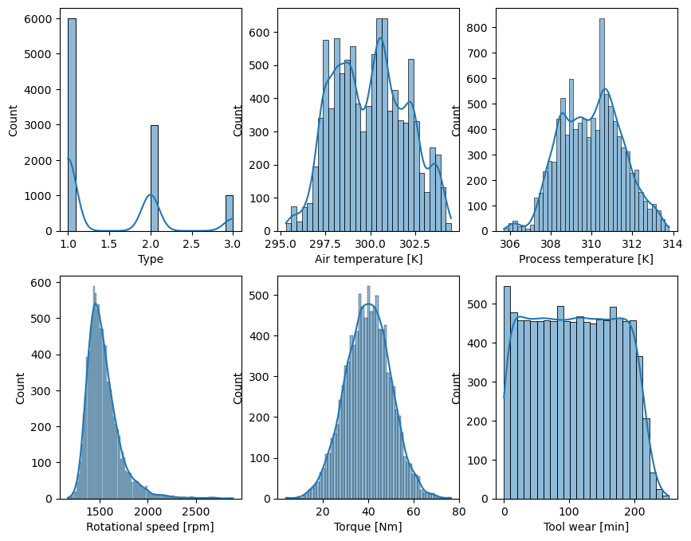

```python
plt.figure(figsize=(10,8))
for i, col in enumerate(X.columns, 1):
    plt.subplot(2,3,i)
    sns.histplot(df[col],kde=True)
```

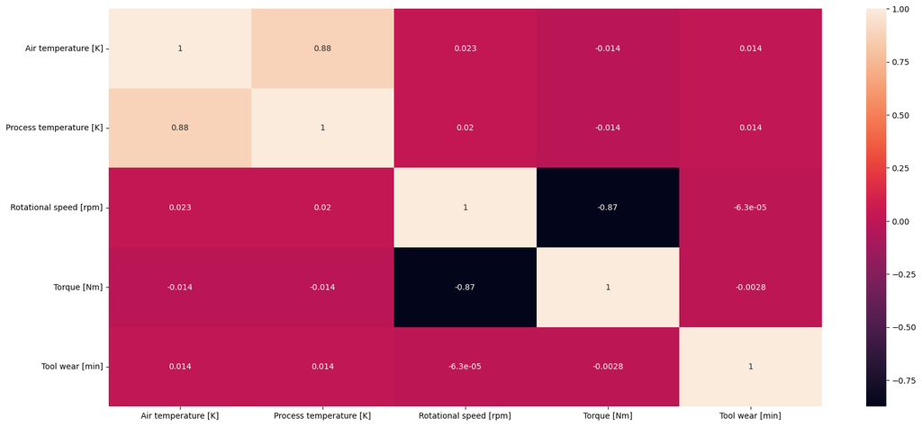

```python
correlation = df.corr()
f, ax = plt.subplots(figsize=(20, 9))
sns.heatmap(correlation, vmax=1, annot=True)
```

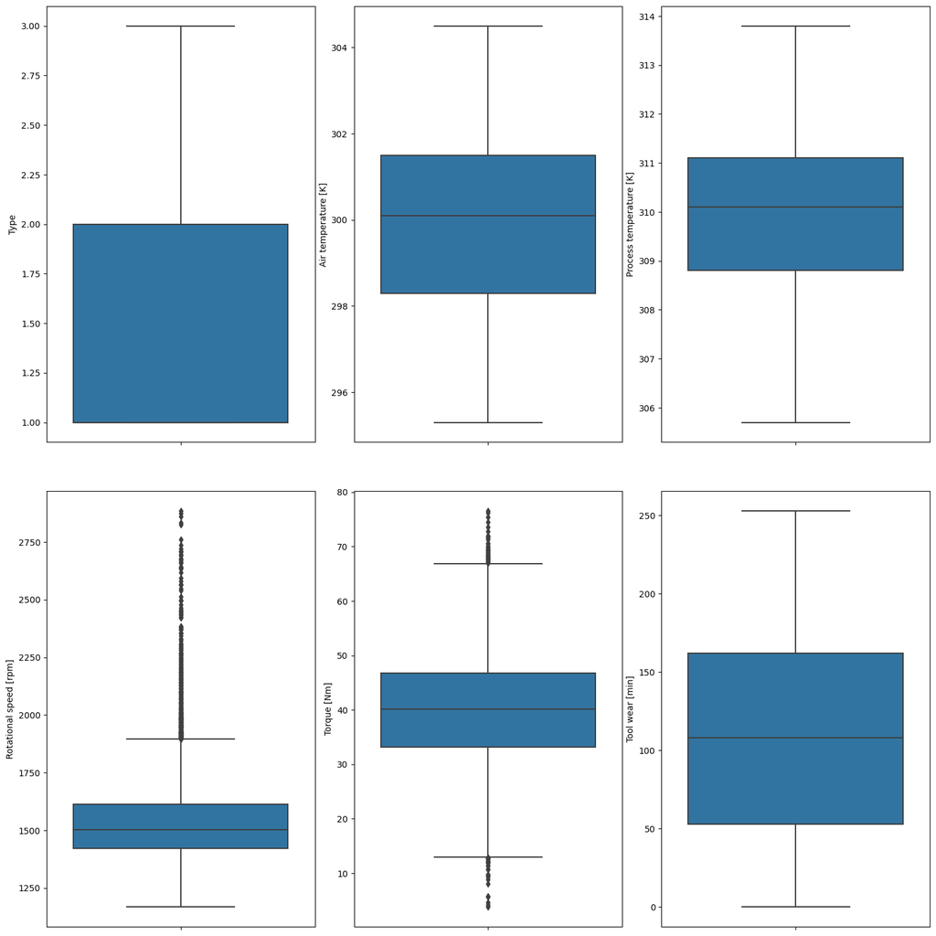

```python
fig, axs = plt.subplots(nrows=2, ncols=3, figsize=(15, 15))
index = 0
axs = axs.flatten()
for k, v in X.items():
    sns.boxplot(y=k, data=df, ax=axs[index])
    index += 1
plt.tight_layout(pad=0.5, w_pad=0.5, h_pad=5.0)
```

### Data Scaling

We scale the data here to fix some data imbalance issues.

```python
df.columns = df.columns.astype("str")
rotspeed = df.columns.to_list().pop(3) # im not doing anything with this yet
target = df.columns.to_list().pop(-1)
#target = failure type, rot speed = rotational speed
```

```python
from imblearn.combine import SMOTETomek
ugh = SMOTETomek(random_state = 42)
x_res, y_res = ugh.fit_resample(X, y)
x_res.shape, y_res.shape
```

```
((57870, 6), (57870,))
```

```python
df2 = pd.concat([pd.DataFrame(x_res), pd.DataFrame(y_res)], axis = 1)
df2.columns = df.columns
df2.head()
```

|  | Type | Air temperature [K] | Process temperature [K] | Rotational speed [rpm] | Torque [Nm] | Tool wear [min] | Failure Type |
| --- | --- | --- | --- | --- | --- | --- | --- |
| 0 | 2.0 | 298.1 | 308.6 | 1551 | 42.8 | 0 | 1 |
| 1 | 1.0 | 298.2 | 308.7 | 1408 | 46.3 | 3 | 1 |
| 2 | 1.0 | 298.1 | 308.5 | 1498 | 49.4 | 5 | 1 |
| 3 | 1.0 | 298.2 | 308.6 | 1433 | 39.5 | 7 | 1 |
| 4 | 1.0 | 298.2 | 308.7 | 1408 | 40.0 | 9 | 1 |

### Data Splitting

```python
X = df2.drop(columns=["Failure Type"] , axis=1).values
y = df2["Failure Type"].astype('int').values
```

```python
from sklearn.model_selection import train_test_split
X_train,X_test,y_train,y_test = train_test_split(X,y,test_size=0.2,random_state=21)
len(X_train), len(y_train), len(X_test), len(y_test)
```

```
(46296, 46296, 11574, 11574)
```

```python
from sklearn.preprocessing import StandardScaler, RobustScaler, MinMaxScaler
sc = RobustScaler()
X_train = sc.fit_transform(X_train)
X_test = sc.transform(X_test)
```

### Data Model Selection

Target variable: Here we want to predict the TYPE of failure (ie, if it will fail, and what type of failure would it be if it fails). Hence, we are dealing with a CATEGORICAL target. = Classification model

over fitting underfitting model update: k neighbours or generative

We will try

1. Support Vector Machines
2. Logistic Regression
3. Decision Tree
4. Random Forest
5. Balanced Random Forest
6. XGBoost (TBC)

### 1. SVC

```python
from sklearn.metrics import classification_report, cohen_kappa_score, accuracy_score
from sklearn.svm import SVC
```

```python
from sklearn.svm import SVC
from sklearn.metrics import accuracy_score
gammas = [0.001, 0.1, 1, 0.01, 10]
cs = [0.1, 1, 10, 100]
kernels = ["linear", "rbf"]
res = []

for kernel in kernels:
    for gamma in gammas:
        for c in cs:
            classifier = SVC(kernel=kernel, gamma=gamma, C=c)

            # train the model
            classifier.fit(X_train, y_train)

            # predict the credit score based on testing dataset
            y_pred = classifier.predict(X_test)

            # get the accuracy value
            accuracy = accuracy_score(y_test, y_pred)

            print("Accuracy:", accuracy, ", Kernel:", kernel, ", C:", c, ", Gamma:", gamma)
            res.append(accuracy)

print("\nHighest accuracy:", max(res))
```

[output not shown]

```python
from sklearn.metrics import classification_report
from sklearn.metrics import cohen_kappa_score

classifier = SVC(kernel='rbf', gamma=10, C=10)
classifier.fit(X_train, y_train)
y_pred = classifier.predict(X_test)
qwk = cohen_kappa_score(y_test, y_pred, weights="quadratic")

print(classification_report(y_test, y_pred))
print("Accuracy:", accuracy_score(y_test, y_pred) )
print("QWK:", qwk)
```

```
              precision    recall  f1-score   support

           1       1.00      0.97      0.98      1940
           2       1.00      1.00      1.00      1953
           3       1.00      1.00      1.00      1913
           4       1.00      1.00      1.00      1859
           5       0.99      1.00      0.99      1895
           6       0.99      1.00      1.00      2014

    accuracy                           0.99     11574
   macro avg       0.99      0.99      0.99     11574
weighted avg       0.99      0.99      0.99     11574

Accuracy: 0.9944703646103336
QWK: 0.9856519448560286
```

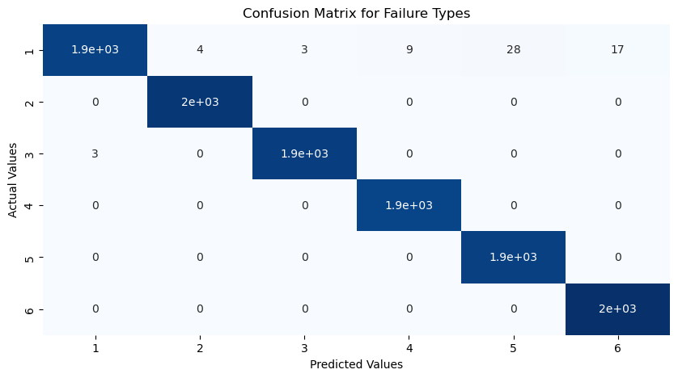

```python
from sklearn.metrics import confusion_matrix
matrix = confusion_matrix(y_test, y_pred, labels=[1, 2, 3, 4, 5, 6])
lst = [1, 2, 3, 4, 5, 6]
cm_df = pd.DataFrame(matrix, index = lst, columns = lst)

plt.figure(figsize=(10,5))
sns.heatmap(cm_df, annot=True, cbar=False, cmap="Blues")
plt.title('Confusion Matrix for Failure Types')
plt.ylabel('Actual Values')
plt.xlabel('Predicted Values')
plt.show()
```

```python
# from sklearn.linear_model import LogisticRegressionCV

# # Train the classifier with cost-sensitive learning
# classifier = LogisticRegressionCV(class_weight='balanced')
# classifier.fit(X_train, y_train)
# y_pred = classifier.predict(X_test)
# score = classifier.score(X_test, y_test)
# print(score)
# print(classification_report(y_test, y_pred))
```

```python
y_pred = classifier.predict(X_test)
```

```python
from sklearn.metrics import confusion_matrix
matrix = confusion_matrix(y_test, y_pred, labels=[1, 2, 3, 4, 5, 6])
lst = [1, 2, 3, 4, 5, 6]
cm_df = pd.DataFrame(matrix, index = lst, columns = lst)

plt.figure(figsize=(10,5))
sns.heatmap(cm_df, annot=True, cbar=False, cmap="Blues")
plt.title('Confusion Matrix for Failure Types')
plt.ylabel('Actual Values')
plt.xlabel('Predicted Values')
plt.show()
```

[output not shown]

```python
accuracy_score(y_test, y_pred)
```

[output not shown]

```python
qwk = cohen_kappa_score(y_test, y_pred, weights='quadratic')
qwk
```

[output not shown]

```python
# from sklearn.linear_model import LogisticRegression
# logreg = LogisticRegression()
# logreg.fit(X_train, y_train)
# y_pred_lr = logreg.predict(X_test)

# log_train = round(logreg.score(X_train, y_train) * 100, 2)
# log_accuracy = round(accuracy_score(y_pred_lr, y_test) * 100, 2)

# print("Model Accuracy Score :",log_accuracy ,"%")
# print("Classification_Report: \n",classification_report(y_test,y_pred_lr))
```

```python
# Decision Tree Classifier
from sklearn.tree import DecisionTreeClassifier
decision = DecisionTreeClassifier()
decision.fit(X_train, y_train)
y_pred_dec = decision.predict(X_test)

decision_train = round(decision.score(X_train, y_train) * 100, 2)
decision_accuracy = round(accuracy_score(y_pred_dec, y_test) * 100, 2)

print("Model Accuracy Score :",decision_accuracy ,"%")
print("Classification_Report: \n",classification_report(y_test,y_pred_dec))
```

```
Model Accuracy Score : 99.08 %
Classification_Report:
               precision    recall  f1-score   support

           1       0.98      0.96      0.97      1940
           2       1.00      0.99      1.00      1953
           3       1.00      1.00      1.00      1913
           4       1.00      1.00      1.00      1859
           5       0.99      1.00      0.99      1895
           6       0.99      0.99      0.99      2014

    accuracy                           0.99     11574
   macro avg       0.99      0.99      0.99     11574
weighted avg       0.99      0.99      0.99     11574
```

```python
#Random Forest Classifier
from sklearn.ensemble import RandomForestClassifier
random_forest = RandomForestClassifier(n_estimators=100)
random_forest.fit(X_train, y_train)
y_pred_rf = random_forest.predict(X_test)
random_forest.score(X_train, y_train)

random_forest_train = round(random_forest.score(X_train, y_train) * 100, 2)
random_forest_accuracy = round(accuracy_score(y_pred_rf, y_test) * 100, 2)

print("Model Accuracy Score :",random_forest_accuracy ,"%")
print("Classification_Report: \n",classification_report(y_test,y_pred_rf))
```

```
Model Accuracy Score : 99.59 %
Classification_Report:
               precision    recall  f1-score   support

           1       1.00      0.98      0.99      1940
           2       1.00      1.00      1.00      1953
           3       1.00      1.00      1.00      1913
           4       1.00      1.00      1.00      1859
           5       0.99      1.00      1.00      1895
           6       1.00      1.00      1.00      2014

    accuracy                           1.00     11574
   macro avg       1.00      1.00      1.00     11574
weighted avg       1.00      1.00      1.00     11574
```

```python
#Balanced Random Forest Classifier under IMBLearn
from imblearn.ensemble import BalancedRandomForestClassifier
random_forest = BalancedRandomForestClassifier(n_estimators=100)
random_forest.fit(X_train, y_train)
y_pred_rf = random_forest.predict(X_test)
random_forest.score(X_train, y_train)

random_forest_train = round(random_forest.score(X_train, y_train) * 100, 2)
random_forest_accuracy = round(accuracy_score(y_pred_rf, y_test) * 100, 2)

print("Model Accuracy Score :",random_forest_accuracy ,"%")
print("Classification_Report: \n",classification_report(y_test,y_pred_rf))
```

```
Model Accuracy Score : 99.57 %
Classification_Report:
               precision    recall  f1-score   support

           1       1.00      0.98      0.99      1940
           2       1.00      1.00      1.00      1953
           3       1.00      1.00      1.00      1913
           4       1.00      1.00      1.00      1859
           5       0.99      1.00      0.99      1895
           6       1.00      1.00      1.00      2014

    accuracy                           1.00     11574
   macro avg       1.00      1.00      1.00     11574
weighted avg       1.00      1.00      1.00     11574
```